# Notebook

[Sebastian Raschka](http://sebastianraschka.com)

last updated: 05/27/2014

- [Open in IPython nbviewer](http://nbviewer.ipython.org/github/rasbt/One-Python-benchmark-per-day/blob/master/ipython_nbs/day8_sqrt_and_exp.ipynb?create=1)
- [Link to this IPython notebook on Github](https://github.com/rasbt/One-Python-benchmark-per-day/blob/master/ipython_nbs/day8_sqrt_and_exp.ipynb)
- [Link to the GitHub Repository One-Python-benchmark-per-day](https://github.com/rasbt/One-Python-benchmark-per-day)

# Day 8 - One Python Benchmark per Day

## Calculating square roots and exponents

I would be happy to hear your comments and suggestions.  
Please feel free to drop me a note via [twitter](https://twitter.com/rasbt), , or [google+](https://plus.google.com/118404394130788869227).

For this benchmark, I only want to focus on the simplest approaches that don't require any additional libraries or modules that are not part of Python's in-built functions or the standard library.  
Why? Because in most simple Python scripts I often see people using the math module for those calculations and I was curious to see if we are not better off using ,e.g., the basic arithmetic operator $x^{0.5}$ and the in-built `pow` function for exponential functions.

**-> skip to the results**

## Square root functions

- `math.sqrt(x)`
- `x**0.5`

**Note that we'll import the math.sqrt() and math.pow() functions into the global namespace to reduce the overhead:**

```python
import math
from math import sqrt as math_sqrt

x = 81
%timeit math_sqrt(x)
%timeit math.sqrt(x)
```

```
10000000 loops, best of 3: 140 ns per loop
10000000 loops, best of 3: 177 ns per loop
```

```python
x = 988
assert(math_sqrt(x) == x**0.5)
print('both functions produce similar results')
```

```
both functions produce similar results
```

## Power *n* functions

- `math.pow(x, n)`
- `pow(x, n)`
- `x**n`

```python
from math import pow as math_pow

x = 3.3
n = 4
assert(math_pow(x, n) == pow(x, n) == x**n)
print('All functions produce similar results')
```

```
All functions produce similar results
```

## Timing square root

```python
import timeit

test_sqrt = [12345.54321, 54756, 23423422, 999999999999999]

timings_sqrt = {'math_module':[], 'arithmetic':[]}

for x in test_sqrt:
    timings_sqrt['math_module'].append(min(timeit.Timer('math_sqrt(x)',
                      'from __main__ import x, math_sqrt')
                              .repeat(repeat=100, number=1000)))
    timings_sqrt['arithmetic'].append(min(timeit.Timer('x**0.5',
                      'from __main__ import x')
                              .repeat(repeat=100, number=1000)))
```

## Timing power *n*

```python
import timeit

test_pow = list(range(1,13))
funcs_pow = ['math_module', 'inbuilt', 'arithmetic']

timings_pow = {f:[] for f in funcs_pow}

for n in test_pow:
    timings_pow['math_module'].append(min(timeit.Timer('math_pow(n, n)',
                      'from __main__ import n, math_pow')
                              .repeat(repeat=100, number=1000)))
    timings_pow['inbuilt'].append(min(timeit.Timer('pow(n, n)',
                      'from __main__ import n')
                              .repeat(repeat=100, number=1000)))
    timings_pow['arithmetic'].append(min(timeit.Timer('n**n',
                      'from __main__ import n')
                              .repeat(repeat=100, number=1000)))
```

## Setting up plots

```python
import platform
import multiprocessing

def print_sysinfo():
    print('\nsystem   :', platform.system())
    print('release  :', platform.release())
    print('machine  :', platform.machine())
    print('processor:', platform.processor())
    print('interpreter:', platform.architecture()[0])
    print('CPU count  :', multiprocessing.cpu_count())

    print('\nPython version', platform.python_version())
    print('compiler', platform.python_compiler())
    print('\n\n')
```

```python
%matplotlib inline
```

```python
import matplotlib.pyplot as plt

def plot_figures():

    fig = plt.figure(figsize=(8,4))
    plt.plot(range(len(test_sqrt)), timings_sqrt['math_module'],
              alpha=0.5, label='math.sqrt(x)', marker='o', lw=2)
    plt.plot(range(len(test_sqrt)), timings_sqrt['arithmetic'],
              alpha=0.5, label='x**0.5', marker='o', lw=2)
    plt.legend(loc='upper left')
    plt.xticks(range(len(test_sqrt)), ['$\sqrt{%s}$'%(x) for x in test_sqrt])
    plt.grid()
    plt.ylabel('time in milliseconds')

    plt.show()

    fig = plt.figure(figsize=(8,4))
    plt.plot(range(len(test_pow)), timings_pow['math_module'],
              alpha=0.5, label='math.pow(x, n)', marker='o', lw=2)
    plt.plot(range(len(test_pow)), timings_pow['inbuilt'],
              alpha=0.5, label='pow(x, n)', marker='o', lw=2)
    plt.plot(range(len(test_pow)), timings_pow['arithmetic'],
              alpha=0.5, label='x**n', marker='o', lw=2)
    plt.legend(loc='upper left')
    plt.xticks(range(len(test_pow)), ['$%s^{%s}$'%(x, x) for x in test_pow])
    plt.grid()
    plt.ylabel('time in milliseconds')
```

# Results

```
system   : Darwin
release  : 13.1.0
machine  : x86_64
processor: i386
interpreter: 64bit
CPU count  : 4

Python version 3.4.0
compiler GCC 4.2.1 (Apple Inc. build 5577)
```

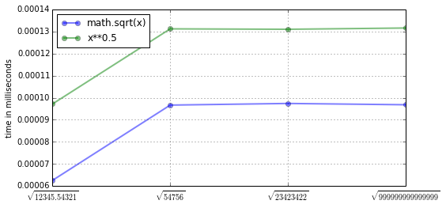

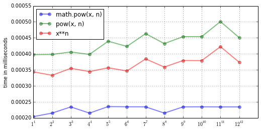

```python
print_sysinfo()
plot_figures()
```

## Conclusion

Despite the **additional name-lookup** for the `math`-module functions, those approaches are still faster than the in-built `**` operator and `pow` function.

**Why is the `math` module more efficient?**  
The `math` module uses the C implementations of the square root and power functions which explains the better performance. And `pow()` is really the same as the `**` operator but comes with an additional function call overhead.

However, the math module comes with the disadvantage that it can't handle complex numbers. In those cases we'd need to use the `cmath` module.

```python
(81+2j)**0.5
```

```
(9.000685740426075+0.11110264582492375j)
```

```python
import cmath
cmath.sqrt(81+2j)
```

```
(9.000685740426075+0.11110264582492377j)
```

```python
import math
math.sqrt(81+2j)
```

```
---------------------------------------------------------------------------
TypeError                                 Traceback (most recent call last)
<ipython-input-4-0ed1cc6d12dd> in <module>()
      1 import math
----> 2 math.sqrt(81+2j)

TypeError: can't convert complex to float
```